# Grave Analysis Project

Fortgeschrittenes Praxisprojekt - WS 25/26 LMU Munich

Arsine Chinaryan, Anh Hoang Minh Dang, Felicia Francis Immanuel, Margarita Khachatryan

Supervisor: Yichen Han

Project partners: Irene Högner, Alissa Mittnik

## Outline

**1. Overview & Terminology**

- Grave Analysis Project
- Description of data sets
- Research questions

**2. Data Analysis & Statistical Modeling**

- Data Description
- Data and Modeling Issues
- Model

**3. Discussion**

- Proposal to handle MNAR

## Outline

**1. Overview & Terminology**

- Grave Analysis Project
- Description of data sets
- Research questions

**2. Data Analysis & Statistical Modeling**

**3. Discussion**

## Overview of the Project

**Grave Analysis**: How do different factors influence the ratio of relatedness and unrelatedness in a collective tomb from Mycenaean times?

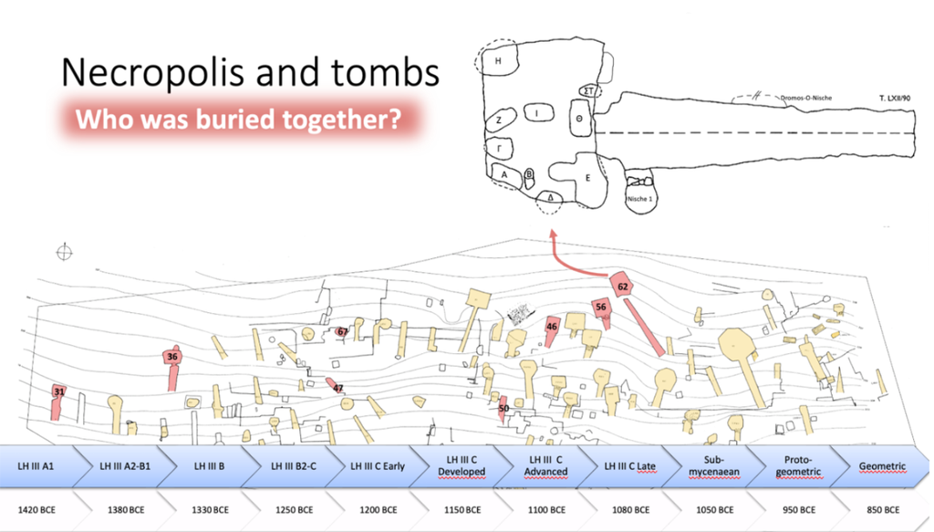

## Description of Data sets

**1. Tomb parameters** - Summary information for each tomb:

**Minimum number of individuals (MNI), Number of analysed individuals, Length of use in years, Percentage of successful samples**, Number of total samples, Number of sampled skeletal element: Petrous bones, Teeth, Talus/Phalanx, other

## Description of Data sets

**1. Tomb parameters** - Summary information for each tomb

**2. Individual metadata** - Information of each sampled individual:

- Analysis ID, Individual ID, Site, 1240k SNPs, Sex, Tomb, Skeletal Element, Age Estimation

## Description of Data sets

**1. Tomb parameters** - Summary information for each tomb

**2. Individual metadata** - Information of each sampled individual

**3. Kinship results:** Pairwise relatedness results between individuals

- **Kinship coefficient**: Genetic relatedness measure between two individuals
- **Relation**: Assigned relationship category (1st / 2nd / 3rd degree)
- **Overlapping SNPs**: Number of shared SNPs used to estimate relatedness
- **Low data**: Indicator that OverlapNSNPs is below the reliability threshold
- Pair individuals ID, Upper & lower Z-score, Allele-sharing statistics (mean, unnormalized, standard error of P0), Kinship coefficient CI (min/max), Kinship coefficient min/max

## Special Remarks

- **Two burial sites**
  - Amfissa (tholos)
  - Elateia (chamber tombs): T31, T36, T46, T50, T56, T62, T67  
    **Note:** Analyze T46, T56, and T62 both as a group and as individual tombs
- **Threshold Rule**
  - Relationship assignments require minimum SNP overlap:
    - **1st degree**: ≥ 500 overlapping SNPs
    - **2nd degree**: ≥ 2,000 overlapping SNPs
    - **3rd degree**: ≥ 15,000 overlapping SNPs
  - Pairs below these thresholds are classified as **uncertain**.

## Research Questions

1. Develop and validate statistical models to predict the **difference between observed and potential relatedness**, using **tomb parameters** (length of use, estimated number of burials, sample success rate) as predictor variables, while accounting for potential confounding factors
2. Build predictive models to estimate **relatedness** patterns using **individual-level covariates** (sex, age and skeletal element of sample), considering that some of these factors may be confounded with DNA preservation quality and sampling success

## Outline

**1. Overview & Terminology**

**2. Data Analysis & Statistical Modeling**

- Data Description
- Data and Modeling Issues
- Model

**3. Discussion**

## Data Description

### DAG (**directed acyclic graph)**

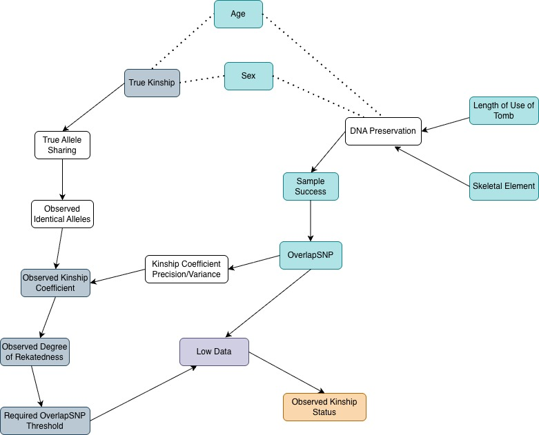

## Data Description

### Absolute relation of MNI and analysed individuals

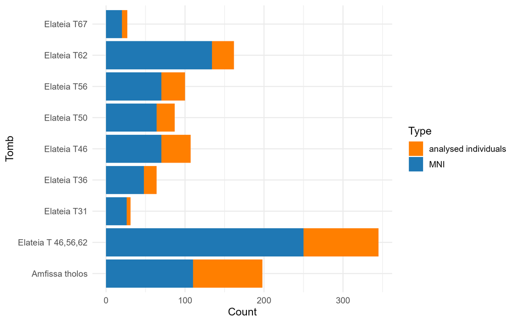

## Data Description

### Relative number of skeletal elements by Sex

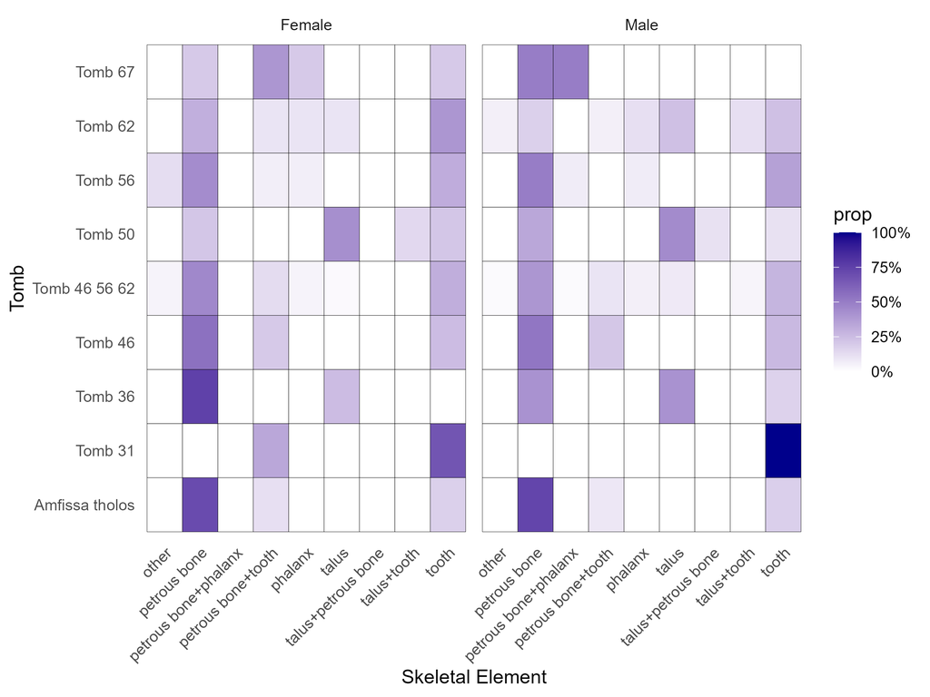

## Data Description

### Relative number of skeletal elements by Age

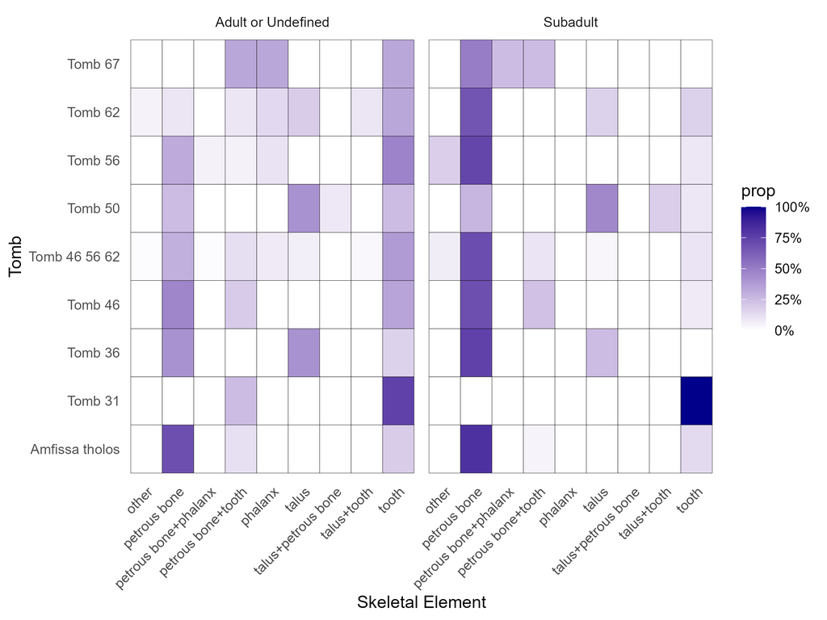

## Data and Modeling Issues

### Tomb-level model

- Too few data (only 8 tombs)
- For too many parameters: length of use, # analysed individuals, effect of 4 types of skeletal elements

$\Rightarrow$ Can not fit a meaningful tomb-level model

## Data and Modeling Issues

### Individual-level model

**1. Unbalanced & sparse Data:**

- Different sample size in each tombs
- Some tombs lack certain skeletal elements entirely
- In some tombs, certain skeletal elements appear only in one sex or one age group

**Solution 1:**

$\Rightarrow$ Collapse many categories of skeletal elements into high-quality bone (petrous bone) and low-quality bone (the rest)

## Data and Modeling Issues

### Individual-level model

**1. Unbalanced & sparse Data**

**2. Across-tomb modeling:**

- Not only model the pairs with-in one tomb but also **across tombs**
- Each pair has 2 tomb memberships
- Relatedness between A and B is influenced by **both** of their tombs

## Data and Modeling Issues

### Individual-level model

**1. Unbalanced & sparse Data**

**2. Across-tomb modeling**

**3. Repeated observation:**

- Each individual appears in multiple pairs (A-B, A-C, A-D,…)
- Creates non-independent observations
- Residual correlation between pairs sharing the same individual
- Potential bias when individuals have different sampling success or preservation

## Data and Modeling Issues

### Individual-level model

**1. Unbalanced & sparse Data**

**2. Across-tomb modeling**

**3. Repeated observation**

**Solution 2 & 3**

$\Rightarrow$ Multiple membership multiple classiﬁcation (MMMC) model

- This accounts for missing category combinations across tombs, cross-tomb structure and controls for repeated measurements on individuals.
- Add random effects for both 2 tombs and 2 individuals

## Data and Modeling Issues

### Individual-level model

**4. Missing values:**

- Pairs below certain thresholds of Overlapping SNPs are classified as **uncertain**
- Missingness Not At Random
- Data being missing is directly dependent on the value of the target variable (relatedness)

**Current solution 4**

$\Rightarrow$ Only use pairs that has over 15.000 Overlapping SNPs to turn it to MAR.

- 1 more proposal to present in the discussion part

## Model

Let $Y_{ij} = 1$ if individuals $i$ and $j$ are related, and $Y_{t,ij} = 0$ otherwise.

We assume:

$$Y_{t,ij} \sim \text{Bernoulli}(\pi_{ij})$$

where $\pi_{ij} = P(\text{related}_{ij} = 1)$.

**Multi-Membership Generalized Linear Mixed Model (MM-GLMM)**

$$\text{logit}(\pi_{ij}) = \alpha + \mathbf{X}_{ij}^{\top}\boldsymbol{\beta}
+ \underbrace{(u_i + u_j)}_{\text{Individual MM}}
+ \underbrace{(v_{T(i)} + v_{T(j)})}_{\text{Tomb MM}}$$

## Model

$$\text{logit}(\pi_{ij}) = \alpha + \mathbf{X}_{ij}^{\top}\boldsymbol{\beta}
+ \underbrace{(u_i + u_j)}_{\text{Individual MM}}
+ \underbrace{(v_{T(i)} + v_{T(j)})}_{\text{Tomb MM}}$$
Where:

- $\alpha$: Global intercept
- $\mathbf{X}_{ij}$: Covariate vector
- $u$: RE for Individual with $u \sim \mathcal{N}(0, \sigma^2_{\text{ind}})$
- $v$: RE for Tomb with $v \sim \mathcal{N}(0, \sigma^2_{\text{tomb}})$

## Model

### Variables

Variables in the model

| related_binary | sex_pair | age_pair | bone_quality | same_tomb | individual1_id | individual2_id | tomb1 | tomb2 |
| --- | --- | --- | --- | --- | --- | --- | --- | --- |
| 0 | XX-XY | mixed | high-low | FALSE | ETA001 | ETA052 | Elateia T31 | Elateia T36 |
| 1 | XX-XY | mixed | high-high | TRUE | AMF014 | AMF063 | Amfissa tholos | Amfissa tholos |
| 0 | XX-XX | both adult/undefined | high-high | TRUE | AMF013 | AMF005 | Amfissa tholos | Amfissa tholos |
| 0 | XX-XX | both adult/undefined | high-high | TRUE | AMF005 | AMF017 | Amfissa tholos | Amfissa tholos |
| 0 | XX-XY | mixed | high-high | FALSE | ETA210 | ETA135 | Elateia T50 | Elateia T46 |
| NA | XX-XY | both adult/undefined | high-high | FALSE | ETA112 | AMF066 | Elateia T46 | Amfissa tholos |
| 0 | XX-XY | mixed | high-low | FALSE | AMF012 | ETA191 | Amfissa tholos | Elateia T50 |
| 0 | XX-XY | mixed | high-high | FALSE | ETA485 | ETA303 | Elateia T67 | Elateia T56 |
| NA | XX-XX | both adult/undefined | high-low | FALSE | ETA458 | ETA326 | Elateia T62 | Elateia T56 |
| 0 | XX-XY | mixed | high-high | FALSE | ETA184 | ETA488 | Elateia T50 | Elateia T67 |

- Use r library “brms” (Bayesian Regression Models using ‘Stan’)
- One version for all separated tombs
- One version with Tomb 46, 56, 62 grouped as 1 tomb

## Model

### Separated tombs

```
 Family: bernoulli
  Links: mu = logit
Formula: related_binary ~ sex_pair + age_pair + bone_quality + same_tomb + (1 | mm(individual1_id, individual2_id)) + (1 | mm(tomb1, tomb2))
   Data: pairs_ind (Number of observations: 13690)
  Draws: 4 chains, each with iter = 6000; warmup = 3000; thin = 1;
         total post-warmup draws = 12000

Multilevel Hyperparameters:
~mmindividual1_idindividual2_id (Number of levels: 176)
              Estimate Est.Error l-95% CI u-95% CI Rhat Bulk_ESS Tail_ESS
sd(Intercept)     2.31      0.28     1.80     2.91 1.00     4025     6763

~mmtomb1tomb2 (Number of levels: 8)
              Estimate Est.Error l-95% CI u-95% CI Rhat Bulk_ESS Tail_ESS
sd(Intercept)     1.07      0.66     0.13     2.78 1.00     2311     2237

Regression Coefficients:
                     Estimate Est.Error l-95% CI u-95% CI Rhat Bulk_ESS
Intercept               -7.84      0.83    -9.46    -6.19 1.00     4873
sex_pairXXMXY            0.91      0.42     0.11     1.77 1.00     8525
sex_pairXYMXY            1.93      0.56     0.86     3.08 1.00     6198
age_pairbothsubadult     1.52      0.54     0.45     2.55 1.00     5623
age_pairmixed            0.57      0.32    -0.05     1.22 1.00     6746
bone_qualityhighMlow    -0.30      0.36    -1.00     0.41 1.00     4872
bone_qualitylowMlow      0.38      0.64    -0.90     1.63 1.00     4277
same_tombTRUE            2.24      0.21     1.82     2.66 1.00    19032
                     Tail_ESS
Intercept                6074
sex_pairXXMXY            9132
sex_pairXYMXY            7903
age_pairbothsubadult     7351
age_pairmixed            9083
bone_qualityhighMlow     6616
bone_qualitylowMlow      5966
same_tombTRUE            8733

Draws were sampled using sampling(NUTS). For each parameter, Bulk_ESS
and Tail_ESS are effective sample size measures, and Rhat is the potential
scale reduction factor on split chains (at convergence, Rhat = 1).
```

## Model

### Grouped tombs

```
 Family: bernoulli
  Links: mu = logit
Formula: related_binary ~ sex_pair + age_pair + bone_quality + same_tomb + (1 | mm(individual1_id, individual2_id)) + (1 | mm(tomb1, tomb2))
   Data: pairs_group (Number of observations: 13690)
  Draws: 4 chains, each with iter = 6000; warmup = 3000; thin = 1;
         total post-warmup draws = 12000

Multilevel Hyperparameters:
~mmindividual1_idindividual2_id (Number of levels: 176)
              Estimate Est.Error l-95% CI u-95% CI Rhat Bulk_ESS Tail_ESS
sd(Intercept)     2.27      0.28     1.76     2.85 1.00     4262     6902

~mmtomb1tomb2 (Number of levels: 6)
              Estimate Est.Error l-95% CI u-95% CI Rhat Bulk_ESS Tail_ESS
sd(Intercept)     1.71      1.09     0.34     4.50 1.00     2964     3708

Regression Coefficients:
                     Estimate Est.Error l-95% CI u-95% CI Rhat Bulk_ESS
Intercept               -8.00      1.16   -10.14    -5.56 1.00     4832
sex_pairXXMXY            0.87      0.42     0.08     1.71 1.00     8445
sex_pairXYMXY            1.93      0.55     0.87     3.04 1.00     6364
age_pairbothsubadult     1.43      0.54     0.37     2.50 1.00     5766
age_pairmixed            0.56      0.32    -0.05     1.21 1.00     6467
bone_qualityhighMlow    -0.35      0.34    -1.01     0.32 1.00     5855
bone_qualitylowMlow      0.42      0.61    -0.77     1.61 1.00     5034
same_tombTRUE            2.57      0.25     2.10     3.08 1.00    20061
                     Tail_ESS
Intercept                5243
sex_pairXXMXY            9076
sex_pairXYMXY            8021
age_pairbothsubadult     7217
age_pairmixed            8138
bone_qualityhighMlow     7692
bone_qualitylowMlow      7172
same_tombTRUE            9117

Draws were sampled using sampling(NUTS). For each parameter, Bulk_ESS
and Tail_ESS are effective sample size measures, and Rhat is the potential
scale reduction factor on split chains (at convergence, Rhat = 1).
```

## Model

### Sampling health (Diagnostic)

**1. R-hat**

- Both model: 1.00

$\Rightarrow$ Very good. 4 different simulation chains have converged to the exact same result.

## Model

### Sampling health (Diagnostic)

1. R-hat: very good

**2. Divergent transitions**

- Both model: 0

$\Rightarrow$ Perfect. Zero cases of divergence.

## Model

### Sampling health (Diagnostic)

1. R-hat: very good
2. Divergent transitions: 0

**3. Effective sample size**

$\Rightarrow$ Extremely high number of independent samples. Indicate reliable estimates and boundaries.

## Model

### Sampling health (Diagnostic)

1. R-hat: very good
2. Divergent transitions: 0
3. Effective Sample Size: extremely high

$\Rightarrow$ The model is healthy and reliable.

## Model

### Interpretation

In logistic regression, $\beta$ are given in Log-Odds

$\Rightarrow$ Interpret as $\text{Odds Ratio} = e^{\beta}$

[figure not shown]

## Outline

**1. Overview & Terminology**

**2. Data Analysis & Statistical Modeling**

**3. Discussion**

- Proposal to handle MNAR
- Modeling Overlap SNPs

## Proposal to handle MNAR

### Background: MNAR in Kinship Data

- Relatedness labels become *uncertain* when overlap SNP is lower than the given threshold
- Thresholds depend on degree (1st/2nd/3rd)
- Missingness is **Missing Not At Random**

## Proposal to handle MNAR

### Statistical reasoning

**From the statistical reference we use:**  
“If missingness depends on an auxiliary variable Z, then including Z in the model makes the missing-data mechanism satisfy MAR instead of MNAR.”

In this case:

- Z = overlap_snps (continuous data-quality variable)
- low_data = threshold flag (encoding whether the overlap is insufficient for that degree)

=> **Include both overlap and low_data in the relatedness model**

## Proposal to handle MNAR

### **Used** model **and data:**

- Multi-Membership Generalized Linear Mixed Model(MM-GLMM) with random effects for both 2 tombs and 2 individuals
- Use the whole data without marking anything uncertain

## Outline

**1. Overview & Terminology**

**2. Data Analysis & Statistical Modeling**

**3. Discussion**

- Proposal to handle MNAR

- Modeling Overlap SNPs

## Modeling Overlap SNPs

### Motivation

Archaeological and biological factors influencing DNA preservation:

- skeletal element
- tomb sample success and length of use
- age and sex

DNA Preservation Factors → Overlap SNPs → Uncertainty in Relatedness

Therefore:

- **Overlap is the key data-quality variable**
- It triggers uncertainty (MNAR) in kinship labels

## Modeling Overlap SNPs

### Model

Gaussian GLM with an identity link

$$\mathbb{E}[\text{Overlap}_{ij}]
= \alpha + \mathbf{X}_{ij}^{\top}\boldsymbol{\beta},
\qquad
\text{Overlap}_{ij} \sim \mathcal{N}(\mu_{ij},\sigma^2).$$

GLM was chosen because:

- outcome is continuous
- predictors are a mix of categorical and numeric
- interpretation is straightforward

## Modeling Overlap SNPs

### Model

```
Call:  glm(formula = overlap_sc ~ same_tomb + sex_pair + age_pair +
    bone_quality + sample_success_min + length_shared, family = gaussian(link = "identity"),
    data = kinship_result_m)

Coefficients:
          (Intercept)          same_tombTRUE          sex_pairXX-XY
            0.4738636              0.0124988             -0.0094534
        sex_pairXY-XY  age_pairboth subadult          age_pairmixed
           -0.0286143              0.1664220              0.0732162
 bone_qualityhigh-low    bone_qualitylow-low     sample_success_min
           -0.6415350             -0.8391720              0.4393446
        length_shared
           -0.0006005

Degrees of Freedom: 27729 Total (i.e. Null);  27720 Residual
Null Deviance:      27730
Residual Deviance: 23790    AIC: 74460
```

## Modeling Overlap SNPs

### Interpretation

1. Lower bone quality -> low overlap
2. Higher tomb sampling success -> better overlap
3. Subadults -> higher overlap
4. Same tomb -> negligible influence

   $\Rightarrow$ Overlap NSPs is mainly driven by bone quality and tomb-level sampling success

## Sources

Multiple membership model:

https://journals.sagepub.com/doi/epdf/10.1177/1471082X0100100202

https://www.youtube.com/watch?v=ob-VAapo3w4

GLMM:

https://stats.stackexchange.com/questions/626546/how-does-lme4-handle-participants-who-only-have-data-for-only-one-level-of-a-cat

https://www.tjmahr.com/plotting-partial-pooling-in-mixed-effects-models/

Variable Z in MNAR:

https://arxiv.org/pdf/2404.04905

brms library:

https://mc-stan.org/learn-stan/diagnostics-warnings.html

https://easystats.github.io/bayestestR/reference/effective_sample.html

## Appendix

### Proposal to handle MNAR: Model

```
 Family: bernoulli
  Links: mu = logit
Formula: related_binary ~ overlap_sc + low_data_fac + age_pair + sex_pair + bone_quality + same_tomb + (1 | mm(individual1_id, individual2_id)) + (1 | mm(tomb1, tomb2))
   Data: kinship_result_m (Number of observations: 27730)
  Draws: 4 chains, each with iter = 6000; warmup = 3000; thin = 1;
         total post-warmup draws = 12000

Multilevel Hyperparameters:
~mmindividual1_idindividual2_id (Number of levels: 235)
              Estimate Est.Error l-95% CI u-95% CI Rhat Bulk_ESS Tail_ESS
sd(Intercept)     4.23      0.24     3.78     4.73 1.00      844     2133

~mmtomb1tomb2 (Number of levels: 8)
              Estimate Est.Error l-95% CI u-95% CI Rhat Bulk_ESS Tail_ESS
sd(Intercept)     0.56      0.48     0.02     1.79 1.01      508     1474

Regression Coefficients:
                     Estimate Est.Error l-95% CI u-95% CI Rhat Bulk_ESS
Intercept               -3.81      0.66    -4.95    -2.36 1.00      805
overlap_sc               0.43      0.12     0.19     0.66 1.00     8427
low_data_facyes         -1.63      0.12    -1.87    -1.40 1.00     8814
age_pairbothsubadult    -0.04      0.53    -1.09     0.98 1.01      845
age_pairmixed           -0.12      0.27    -0.65     0.40 1.01      853
sex_pairXXMXY            0.04      0.26    -0.46     0.54 1.01      633
sex_pairXYMXY            0.31      0.50    -0.67     1.30 1.01      598
bone_qualityhighMlow     0.72      0.26     0.21     1.23 1.01      747
bone_qualitylowMlow      1.63      0.51     0.64     2.63 1.01      729
same_tombTRUE            0.62      0.07     0.48     0.77 1.00     9909
                     Tail_ESS
Intercept                1588
overlap_sc               7797
low_data_facyes          8566
age_pairbothsubadult     1675
age_pairmixed            1781
sex_pairXXMXY            1011
sex_pairXYMXY             879
bone_qualityhighMlow     1595
bone_qualitylowMlow      1720
same_tombTRUE            8593

Draws were sampled using sampling(NUTS). For each parameter, Bulk_ESS
and Tail_ESS are effective sample size measures, and Rhat is the potential
scale reduction factor on split chains (at convergence, Rhat = 1).
```

## Appendix

### Proposal to handle MNAR: Sampling health (Diagnostic)

- **R-hat ≈ 1.00 or 1.01** → chains mixed well
- **Bulk ESS, Tail ESS reasonable** → stable posterior estimates
- **Very few divergent transactions** → sampler explored geometry correctly

  $\Rightarrow$ The diagnostics indicate reliable posterior estimation.

## Appendix

### Proposal to handle MNAR: Interpretation

[figure not shown]

## Appendix

### Proposal to handle MNAR: Interpreting the Low Bone Quality Coefficient

- **Logically**, and as confirmed by our Overlap Model,
  - good-quality bone → **higher** overlap
  - low-quality bone → **lower** overlap
- However, in the Relatedness Model, **low bone quality shows a positive coefficient**.

**Why?**

This is a **conditional statistical effect**, not a biological one.

- Because **overlap_sc is already included in the model**, it absorbs the main effect of DNA preservation.
- After adjusting for overlap, **bone quality no longer represents DNA quality**.
- Instead, its remaining variation correlates with other factors in the dataset

  (e.g., specific tombs or individuals that happen to contain more relatives).

## Appendix

### Proposal to handle MNAR: Conclusion

This model provides a statistically valid way to address the MNAR mechanism in our dataset and yields reliable estimates of relatedness under realistic archaeological and technical conditions.

[figure not shown]